# Deep Learning part 1

24-Nov-2022

## .Outline

- Recap of the September meeting
- Machine learning
- Deep Learning
- Code Surgery : Image recognition (`R` with `CPU`)

In December:

- Software and hardware for Deep Learning
- Code Surgery : Voice recognition (`Py` with `GPU` / `TPU`)

## .September meeting

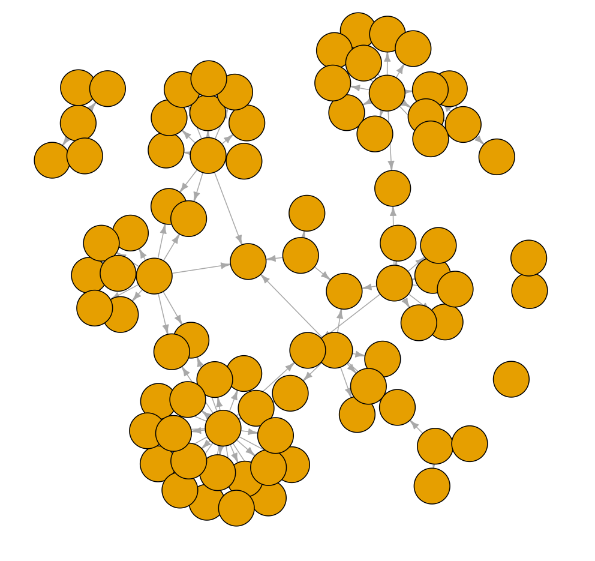

Data Science Meets Law. Network analysis.

## .Machine Learning & Data Science

[figure not shown]

The edible flowers are attractive to the eye and stomach (www.gardengatemagazine.com)

The purpose of ML is to replace a human in some tasks while the purpose of DS is to explain the world to a human. Both still use the same concepts.

## .Machine Learning & Classical Programming

[interactive chart not shown]

## .Deep Learning

Deep Learning is Machine Learning using Artificial Neural Networks.

The “deep” adjective refers to multiple layers in a network.

## .Artificial Neural Network

[interactive chart not shown]

## .Applications

- Automatic speech recognition
- Image recognition
- Visual art processing
- Natural language processing
- Drug discovery and toxicology
- Customer relationship management
- Recommendation systems
- Bioinformatics
- Medical image analysis
- Mobile advertising
- Image restoration
- Financial fraud detection
- Image generating
- Military
- Partial differential equations
- Image Reconstruction
- Epigenetic clock

## . Application limitations

- Model explainability (loans)

In the [EU](https://www.eba.europa.eu/regulation-and-policy/credit-risk/guidelines-on-loan-origination-and-monitoring) and in particular in [PL](https://www.knf.gov.pl/knf/pl/komponenty/img/Komunikat_UKNF_ws_prawa_do_uzyskania_wyjasnien_nt_oceny_zdolnosci_kredytowej_wersja_szczegolowa_70332.pdf) the bank must provide information on the measures that the applicant should take to remove the negative effects determining the lender’s decision not to grant the loan.

- Theory (it works, but why?)
- Cyber threat (vulnerability to hacking and fraud)
- Reliance on human microwork (Amazon Mechanical Turk)

## .Code Surgery

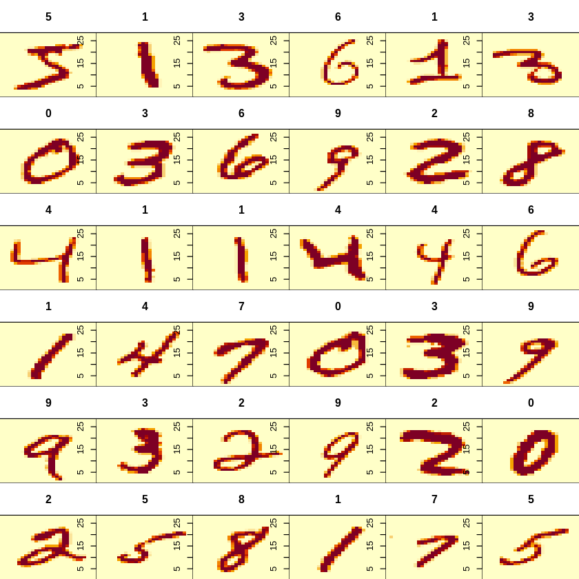

Image recognition (`R` with `CPU`)